# Assignment 3 - Supervised Learning

## *Allison Young*

Netid: *ary13*

## 1

### [40 points] From theory to practice: classification through logistic regression

#### Introduction

For this problem you will derive, implement through gradient descent, and test the performance of a logistic regression classifier for a binary classification problem.

In this case, we'll assume our logistic regression problem will be applied to a two dimensional feature space. Our logistic regression model is:

$$f(\mathbf{x}_i,\mathbf{w})=\sigma(\mathbf{w}^T \mathbf{x}_i)$$

where the sigmoid function is defined as $\sigma(x) = \frac{e^x}{1+e^x}$. Also, since this is a two-dimensional problem, we define $\mathbf{w}^T \mathbf{x}_i = w_0 x_{i,0} + w_1 x_{i,1} + w_2 x_{i,2}$ and here, $x_{i,0} \triangleq 1$

As in class, we will interpret the response of the logistic regression classifier to be the likelihood of the data given the model. For one sample, $(y_i, \mathbf{x_i})$, this is given as:

$$P(Y=y_i|X=x_i) = f(\mathbf{x}_i,\mathbf{w})=\sigma(\mathbf{w}^T \mathbf{x}_i)$$

#### Find the cost function that we can use to choose the model parameters, $\mathbf{w}$, that best fit the training data.

**(a)** What is the likelihood function of the data that we will wish to maximize?

**(b)** Since a logarithm is a monotonic function, maximizing the $f(x)$ is equivalent to maximizing $\ln [f(x)]$. Express part (a) as a cost function of the model parameters, $C(\mathbf{w})$, that is the negative of the logarithm of (a).

**(c)** Calculate the gradient of the cost function with respect to the model parameters $\nabla_{\mathbf{w}}C(\mathbf{w})$. Express this in terms of the partial derivatives of the cost function with respect to each of the parameters, e.g. $\nabla_{\mathbf{w}}C(\mathbf{w}) = \left[\frac{\partial C}{\partial w_0}, \frac{\partial C}{\partial w_1}, \frac{\partial C}{\partial w_2}\right]$.

**(d)** Write out the gradient descent update equation, assuming $\eta$ represents the learning rate.

#### Prepare and plot your data

**(e)** Load the data and scatter plot the data by class. In the data folder in the same directory of this notebook, you'll find the data in `A3_Q1_data.csv`. This file contains the binary class labels, $y$, and the features $x_1$ and $x_2$. Comment on the data: do the data appear separable? Why might logistic regression be a good choice for these data or not?

**(f)** Do the data require any preprocessing due to missing values, scale differences, etc? If so, how did you remediate this?

#### Implement gradient descent and your logistic regression algorithm

**(g)** Create a function or class to implement your logistic regression. It should take as inputs the model parameters, $\mathbf{w}=\left[w_0,w_1,w_2\right]$, and output the class confidence probabilities, $P(Y=y_i|X=x_i)$.

**(h)** Create a function that computes the cost function $C(\mathbf{w})$ for a given dataset and corresponding class labels.

**(i)** Create a function or class to run gradient descent on your training data. We'll refer to this as "batch" gradient descent since it takes into account the gradient based on all our data at each iteration (or "epoch") of the algorithm. Divide your data into a training and testing set where the test set accounts for 30 percent of the data and the test set the remaining 70 percent. In doing this we'll need to make some assumptions / experiment with the following:

1. The initialization of the algorithm - what should you initialize the model parameters to? For this, randomly initialize the weights to a different values between 0 and 1.
2. The learning rate - how slow/fast should the algorithm proceed in the direction opposite the gradient? This you will experiment with.
3. Stopping criteria - when should the algorithm be finished searching for the optimum? Set this to be when the cost function changes by no more than $10^{-6}$ between iterations. Since we have a weight vector, you can compute this by seeing if the L2 norm of the weight vector changes by no more than $10^{-6}$ between iterations.

**(j)** At each step in the gradient descent algorithm it will produce updated parameter estimates. For each set of estimates, calculate the cost function for both the training and the test data.

**(k)** Show this process for different learning rates by plotting the resulting cost as a function of iteration (or "epoch"). What is the impact that each parameter has on the process and the results? What choices did you make in your chosen approach and why? Use the parameter you choose here for the learning rate for the remainder of this question.

#### Test your model performance through cross validation

**(l)** Test the performance of your trained classifier using K-folds cross validation (while this can be done manually, the scikit-learn package [StratifiedKFolds](http://scikit-learn.org/stable/modules/generated/sklearn.model_selection.StratifiedKFold.html#sklearn.model_selection.StratifiedKFold) may be helpful). Produce Receiver Operating Characteristic Curves (ROC curves) of your cross validated performance.

**(m)** Why do we use cross validation?

**(n)** Make two plots - one of your training data, and one for your test data - with the data scatterplotted and the decision boundary for your classifier. Comment on your decision boundary. Could it be improved?

**(o)** Compare your trained model to random guessing. Show the ROC curve for your model and plot the chance diagonal. What area under the curve (AUC) does your model achieve? How does your model compare in terms of performance?

**ANSWER**

### Q1

### A. Likelihood Function

$$ \prod_{i=1}^{N} \Big( \frac{1}{1+e^{-wx_i}}\ \Big) ^{y_i} \Big(\frac{e^{-wx_i}}{1 + e^{-wx_i}}\Big)^{1-y_i} \ $$

### B. Cost Function

$$ - \sum_{n=1}^N [(1-y_i) (-wx_i)- log(1+e^{-wx_i})] $$

### C. Gradient of the Cost Function

$$ \frac{1}{N} \sum_{n=1}^N \frac{\Delta C (w)}{w_0} = x_0 \Big[(1-y_i) - \frac{e^{-wx_0}}{1 + e^{-wx_0}}\Big] \\\frac{1}{N} \sum_{n=1}^N \frac{\Delta C (w)}{w_1} = x_1 \Big[(1-y_i) - \frac{e^{-wx_1}}{1 + e^{-wx_1}}\Big] \ \\\frac{1}{N} \sum_{n=1}^N \frac{\Delta C (w)}{w_2} = x_2 \Big[(1-y_i) - \frac{e^{-wx_2}}{1 + e^{-wx_2}}\Big] \ $$

### D. Gradient Descent Update Equation

The gradient update equation is defined as $$ x^{(x+i)} = x^i - \eta \nabla f(x^i)$$

given that sigmoid function is defined as $\sigma(x) = \frac{e^x}{1+e^{x}}$ We could replace $\frac{e^{-wx_{i,1}}}{1+e^{-wx_{i,1}}}$ with $1 - \sigma(W^T x_i)$

$$w = w - \dfrac{\eta}{N} \sum_{i = 1}^{N} x_{i}\left((1-y_i)\: - (1-\sigma(\mathbf{w}^T \mathbf{x}_i)\right)$$$$w = w - \dfrac{\eta}{N} \sum_{i = 1}^{N} x_{i}\left(-y_i + \sigma(\mathbf{w}^T \mathbf{x}_i)\right)$$

until $w$ converges on one point.

### E. Prepare and Plot Data

The data appear to overlap greatly in their current form. However if we are able to transform the data so that the two classes move away from one another and create more clear deliniations between classes, one may more easily determine between the classes.

From my understanding, I don't believe logistic regression on its own will be a great solution to the challenge of parsing these classes.

**Code for E below:**

```python
# E
#######################################################################
# Load Data
#######################################################################
import warnings
import pandas as pd
import matplotlib.pyplot as plt
import seaborn as sns
import numpy as np

df = pd.read_csv("./data/A3_Q1_data.csv")
print("Files Loaded")
df["y"] = df["y"].astype(int)
fig = plt.figure(figsize=(12, 8))
g= sns.relplot(x="x1", y="x2", hue="y", data=df, alpha=.6)


g.set_axis_labels("x values", "y values")
g.fig.set_size_inches(6.5, 3.5)

plt.title("Scatterplot of points in 2 Classes", fontsize=14)
plt.show()
warnings.simplefilter('ignore')
```

[output not shown]

### F. Data Preprocessing

An initial look at the data reveals no null values in any of the columns; and the summary data appears as one would expect it should look. The only change I made was to may the y variable an integer rather than a float, as it is a binary classification.

**Code for F below:**

```python
# F
#######################################################################
# Explore and Preprocess Data
#######################################################################

print(df.describe())
print(df['x1'].unique())
print(df['x2'].unique())
print(df.isnull().sum())
```

```python
df.describe()
df2= df.copy()

print("Cell has run")
```

### G. Create function that inputs model parmeters and outputs Confidence probability

Next, I translate the sigmoid, and confidence probability predictions into functions.

**Sigmoid Function**

The sigmoid function takes a parameter of x values and returns the result of passing those values through the sigmoid function:

$\sigma(x) = \frac{e^x}{1+e^x}$

**Confidence Probability Function**

The confidence probabilities are calculated through a function that accepts a data frame, df, and weight vector, w. This function passes the dataframe and weights through the sigmoid function and returns a dataframe of probabilities.

**Code for F below:**

```python
import random
random.seed(26)
#### Create Weight Vector
w=np.zeros((3,1))
for i in range(3):
    w[i]= random.random()


def sigmoid(x):
    return  np.exp(x)/(1+np.exp(x))

def prob(df,w):
    probabil =sigmoid(w[0]*df[:,0]+w[1]*df[:,1]+w[2]*df[:,2])
    return probabil
print(w)
#prob(df2,w)
```

### H. Cost function for a given dataset and corresponding class labels

**Cost Function**

Next, the cost function accepts a data frame of x1 and x2 values, an array of corresponding y values, and a weight vector, w. This function passes the dataframe and weights through the sigmoid function and returns a dataframe of probabilities.

This function first turns the dataframe into a numpy array, as many of the next operations are more easily performed with numpy functionalities. Within the cost function, the label of the y outcome of a feature determines whether the probrability or the complement probability is utilized to calculate the "partial" cost of that feature. The dataframe and weights are then passed to the probability function, where, over the entirety of the arrays, the log of probabilities are added together, and then divided by the number of observations. Finally, this value is returned as a negative value.

**X roll Function**

The xroll function was not ultimately used as a part of the cost function, but it was used in the exploration process to add x0 values of "1" to the observations, to pass to the proability and sigmoid functions, respectively.

**Code for F below:**

```python
#def cost(df):
 #   df['cw']= -(1-df['y'])(-w[i]*df2[:,i])+log(1+power_e)
def cost(Xf,y,w):
    #xroll(df)
    Xf= np.array(Xf)
    partial= y.T.dot(np.log(prob(Xf,w)))+(1-y).T.dot(np.log(1-prob(Xf,w)))
    #print(df2.head())
    return -partial/len(Xf)
    #df.sort_values(by=['col1']
# c = - Y.T.dot(np.log(Y_hat)) - (1-Y).T.dot(np.log(1- Y_hat))
 #       return c / num
def xroll(X):
    xdim = X.shape
    x_0 = np.ones((xdim[0], 1))
    return np.concatenate([x_0, X], axis = 1)

#result=cost(df2,w)
#print(sum(df2['prob']))
print("Cell has run")
##print(df2.head())

#print(result)
```

### I&J. Function that runs gradient descent on training data, produces updated parameter estimates and calculates the cost function for both the training and test data

**Gradient Descent Function**

Finally, I created a gradient descent function. This function is likely overly complex in its design (as it has some repetition of functionality in terms of being used for test and training data); however, it functions in a way that makes charting different model variations easier.

The function I developed accepts both X and y arrays for the training(Xf,y) and the test data(Xf2,y2), followed by a weight vector (w), change value, and learning rate(eta). This function trains only on the training data, and iterates over updates to the weight vector based on the learning rate, which determines the "steps" between function iterations.

The difference between previous and current w values are used to determine when the function stops, and the final weight vector (w) is returned, along with the corresponding cost arrays for the test and training datasets. These arrays calculate the costs that correspond to each epoch of the data. These values can be used later to show the impact of different parameters of the model on the behavior of the model.

**Code for I and J below:**

### GRADIENT DESCENT FUNCTION

```python
random.seed(26)
w = np.random.rand(3, 1)
change = 5
eta= .001


def gd(Xf,y,Xf2,y2,w,change, eta):
    epoch=0
    train_cost = []
    test_cost =[]
    while change >= .00001:
        power_e = np.exp(np.dot(w.T, Xf.T))
        frac = power_e/(1 + power_e) #sigmoid
        in_bracket = -y.T + frac
        update = np.dot(in_bracket, Xf)
        w0 = w.copy()
        w = w - eta*update.T/len(Xf)
        change = np.linalg.norm(w-w0)
        epoch += 1
        train_cost.append(cost(Xf,y,w))
        test_cost.append(cost(Xf2,y2,w))
        #if epoch%50 == 0:
         #   print("epoch: {}, Train cost: {} , Test cost: {}".format(epoch,cost(Xf,y,w), cost(Xf2,y2,w)))
    #print(w,cost(Xf,y,w))
    #print(w, cost(Xf2,y2,w))
    #print(w0,cost(Xf,w0))
    #print(w0, cost(Xf2,w0))
    return w, train_cost, test_cost

print("Cell has run")
```

### Divide Data into Test and Training Data

Below is the code utilized to divide the dataset into a training dataset (70% of the observations), and a test dataset (30% of the observations).

I also created the logistic regression using these datasetsin this set of code.

```python
import warnings

from sklearn import datasets, linear_model
from sklearn.model_selection import train_test_split
from matplotlib import pyplot as plt
from sklearn.linear_model import LogisticRegression
from sklearn.cross_validation import train_test_split
import seaborn as sns
# create training and testing vars

df.head()
X= df[['x1','x2']]
Y= df['y']

X_train, X_test, y_train, y_test = train_test_split(X,Y, test_size=((.3)))
print(X_train.shape, y_train.shape)
print(X_test.shape, y_test.shape)
#np.reshape(y_train.shape, (-1,1))

from sklearn.linear_model import LogisticRegression
from sklearn import metrics

logreg = LogisticRegression()
logreg.fit(X_train, y_train)

warnings.simplefilter('ignore')
```

```python
#parameters to initialize
# w (randomly assign)
# eta- experiment with
# stopping criteria
# change
# batches/epochs

#parameter estimates, calculate cost function for training and test data
```

### TRAINING DATA

```python
x = np.array(X_train)
y = np.expand_dims(np.array(y_train), axis = -1)

Xf = np.concatenate([xroll(x)], axis = 1) # this gives x0,x1,x2,
Xy = np.concatenate([xroll(x),y], axis = 1) # this gives x0,x1,x2,y

#Xf = pd.DataFrame(Xf)
#cost(X,w)
print("Cell has run")
```

### TEST DATA

```python
x2 = np.array(X_test)
y2 = np.expand_dims(np.array(y_test), axis = -1)

Xf2 = np.concatenate([xroll(x2)], axis = 1) # this gives x0,x1,x2,
Xy2 = np.concatenate([xroll(x2),y2], axis = 1) # this gives x0,x1,x2,y

print("Cell has run")
```

Below is code I utilized to test and de-bug my gradient descent function.

```python
#print(Xf.shape)
#print(y.shape)
#print(Xf2.shape)
#print(y2.shape)
```

```python
#w, train_cost, test_cost = gd(Xf,y,Xf2,y2,w,change,eta)
#print(w, train_cost,test_cost)
```

```python
### Prediction function
#gd(Xf,y,Xf2,y2,w,change,eta)
predict= prob(Xf2,w)
print(predict[:10], y_test[:10])
```

### K. Adjusting and Exploring Parameters

Below is the code I used to explore and plot different parameters, followed by a summary of my process in doing this and my final paramater selections.

**Code for K below:**

### Change in the learning rate(eta)

```python
#gd(Xf,y,Xf2,y2,w,change,eta)
ETA1 = gd(Xf,y,Xf2,y2, w, 5, .001)
ETA2 = gd(Xf,y,Xf2,y2, w, 5, .1)
ETA3 = gd(Xf,y,Xf2,y2, w, 5, .5)
ETA4 = gd(Xf,y,Xf2,y2, w, 5, 1)
ETA5 = gd(Xf,y,Xf2,y2, w, 5, 3)
ETA6 = gd(Xf,y,Xf2,y2, w, 5, 5)
ETA7 = gd(Xf,y,Xf2,y2, w, 5, .7)
ETA8 = gd(Xf,y,Xf2,y2, w, 5, .6)
ETA9 = gd(Xf,y,Xf2,y2, w, 5, .4)

print("Cell has Run")
```

### Checking Change Variations

```python
C1 = gd(Xf,y,Xf2, y2, w,.001, .4)
C2 = gd(Xf,y,Xf2, y2, w, .01, .4)
C3 = gd(Xf,y,Xf2, y2, w, 1, .4)
C4 = gd(Xf,y,Xf2, y2, w, 10, .4)
# Not a big diference

print("Cell has Run")
```

### Change in the original weight vector (w)

```python
random.seed(1)
w1 = np.random.rand(3, 1)
random.seed(2)
w2 = np.random.rand(3, 1)
random.seed(3)
w3 = np.random.rand(3, 1)
random.seed(4)
w4 = np.random.rand(3, 1)
random.seed(5)
w5 = np.random.rand(3, 1)
random.seed(6)
w6 = np.random.rand(3, 1)
random.seed(7)
w7 = np.random.rand(3, 1)
random.seed(8)
w8 = np.random.rand(3, 1)
random.seed(9)
w9 = np.random.rand(3, 1)

print(w1)
ETAw1 = gd(Xf,y,Xf2,y2, w1, 5, .4)
print(w2)
ETAw2 = gd(Xf,y,Xf2,y2, w2, 5, .4)
print(w3)
ETAw3 = gd(Xf,y,Xf2,y2, w3, 5, .4)
print(w4)
ETAw4 = gd(Xf,y,Xf2,y2, w4, 5, .4)
print(w5)
ETAw5 = gd(Xf,y,Xf2,y2, w5, 5, .4)
print(w6)
ETAw6 = gd(Xf,y,Xf2,y2, w6, 5, .4)
print(w7)
ETAw7 = gd(Xf,y,Xf2,y2, w7, 5, .4)
print(w8)
ETAw8 = gd(Xf,y,Xf2,y2, w8, 5, .4)
print(w9)
ETAw9 = gd(Xf,y,Xf2,y2, w9, 5, .4)


## LARGER RANDOM Ws, slightly larger cost, fewer epochs  (infer- less time, less accurate)
#[[0.61875576]
# [0.61790904]
# [0.81191201]]
#epoch: 50, Train cost: [0.3309581] , Test cost: [0.32928317]
#epoch: 100, Train cost: [0.32902376] , Test cost: [0.32698083]
#epoch: 150, Train cost: [0.32892418] , Test cost: [0.32679867]
#epoch: 200, Train cost: [0.32891778] , Test cost: [0.32677158]
#epoch: 250, Train cost: [0.32891735] , Test cost: [0.32676586]
#[[-0.16495341]
# [-1.91325266]
# [-0.40856013]] [0.32676467]
##

### SMALLER RANDOM Ws, slightly lower cost, many more epochs (infer- more time, more accurate)
#[[0.26284579]
 #[0.64156785]
 #[0.0883543 ]]
#epoch: 50, Train cost: [0.33168808] , Test cost: [0.3298466]
#epoch: 100, Train cost: [0.329162] , Test cost: [0.32705655]
#epoch: 150, Train cost: [0.32895174] , Test cost: [0.32680107]
#epoch: 200, Train cost: [0.32892328] , Test cost: [0.32676658]
#epoch: 250, Train cost: [0.32891844] , Test cost: [0.32676247]
#epoch: 300, Train cost: [0.32891753] , Test cost: [0.32676276]
#epoch: 350, Train cost: [0.32891736] , Test cost: [0.32676334]
#epoch: 400, Train cost: [0.32891732] , Test cost: [0.32676371]
#[[-0.16539916]
 #[-1.91329631]
 #[-0.4089213 ]] [0.32676373]

print("Cell has Run")
```

### Summary from adjusting Parameters

#### Weight Vector (w)

Changes in the weight vector (created by random in this example), primarily impact how long it takes for the function to converge. The weights simply determined the starting point for the gradient descent process (as they determined the starting cost value). From there, they follow the gradient descent function until they converge (as defined by the change threshold).

In summary, the weight vector does not greatly influence outcome; it will be very close to the same value, no matter what the original weights are. The weight vector predominately impacts the time it takes to run the function and the number of iterations it takes to get to the determined "change" threshold.

#### Learning Rate (ETA= .4)

The learning rate alters the rate at which the function changes with each epoch. In a sense, this represents the "Step" change in x, as the slope of the derivative approaches zero. A higher learning rate means the function will take larger steps. Each iteration of the gradient descent will move by the learning rate times the update in the weights, divided by the number of observations.

Therefore, when the "steps" are really large, they may encompass the minimum at zero. When this happens, the function will never converge, because the step continually passes from one side of the minimum to the other, changing the direction of descent, and failing to ultimately progress closer to the minimum. On the otherhand, a lower learning rate means the function will take smaller steps. The smaller the step, the longer the function will take, but the likelihood of reaching a minimum cost that is closer to zero is greater. The smaller step allows the descent to continue in the same direction over multiple iterations, continuing down, rather than skipping back and forth.

#### Summary of Selection Process

To determine the set of parameters on which I finally settled, I started with what seemed to be a reasonable number for "change" given the range of the data in the original data exploration (meaning it wouldn't be higher than the range of the data, nor drastically smaller than a difference between observations. I then isolated the learning rate to experiment with. Using a series of trials, I settled on a general minimum of cost on the training data (other parameters held constant), at the learning rate of .4. I then checked my assumptions on the change threshold, and confirmed it had little influence.

### Plotting Cost by Different Learning Values and Weight Vectors

```python
cost1= ETA1[1]
cost2= ETA2[1]
cost3= ETA3[1]
cost4= ETA4[1]
cost5= ETA5[1]
cost6= ETA6[1]
cost7= ETA7[1]
cost8= ETA8[1]
cost9= ETA9[1]

costw1= ETAw1[1]
costw2= ETAw2[1]
costw3= ETAw3[1]
costw4= ETAw4[1]
costw5= ETAw5[1]
costw6= ETAw6[1]
costw7= ETAw7[1]
costw8= ETAw8[1]
costw9= ETAw9[1]

print("Cell has run")
```

```python
import warnings


fig = plt.figure(figsize=(10, 6))

plt.title('Cost for training data by varying learning rates',fontsize=16)
plt.xlabel('Epochs', fontsize=14)
plt.ylabel('Cost',fontsize=14)
plt.semilogx()
plots = [cost1,cost2,cost3,cost4,cost5,cost6,cost7,cost8,cost9]
labels = ['eta= .001', 'eta  0.1','eta = 0.5','eta = 1','eta = 3', 'eta = 5', 'eta = .7', 'eta = .6', 'eta = .4']
colors = ['orange','b','r','g','cyan','yellow','brown', 'purple', 'pink']
for n,cost in enumerate(plots):
    plt.plot(range(1,len(cost)+1),cost, color = colors[n])
plt.legend(labels= labels)
warnings.simplefilter('ignore')
```

[output not shown]

```python
fig = plt.figure(figsize=(10, 6))

plt.title('Cost for training data with differing weight vectors (eta = .4)', fontsize=16)
plt.xlabel('Epochs', fontsize=14)
plt.ylabel('Cost', fontsize=14)
plt.semilogx()
plots = [costw1,costw2,costw3,costw4,costw5,costw6,costw7,costw8,costw9]
labels = ['w1', 'w2','w3','w4','w5','w6','w7','w8','w9']
colors = ['orange','b','r','g','cyan','yellow','brown', 'purple', 'pink']
for n,cost in enumerate(plots):
    plt.plot(range(1,len(cost)+1),cost, color = colors[n])
plt.legend(labels= labels)
```

[output not shown]

### L. Test your model performance through cross validation, and plot ROC curves for K-fold Classifier

After determining my parameters, I used my training data to perform K-folds cross validataion. This classifier divideds the data into splits based on the number of selected folds. I chose a fold value of 5, which compares 5 iterations of a 20% / 80% split of the training data to further compare and cross validate.

I then plotted the resulting ROC curves for each of these folds, and calculated the area under the curve (AUC). These did not vary much, landing at a mean of approximately an AUC of .93, which is much better than change.

**The code for L is below**:

```python
import random
import numpy as np
from scipy import interp
import matplotlib.pyplot as plt

from sklearn import svm, datasets
from sklearn.metrics import roc_curve, auc
from sklearn.model_selection import StratifiedKFold

import warnings

warnings.simplefilter('ignore')

# #############################################################################
# Classification and ROC analysis

# Run classifier with cross-validation and plot ROC curves
cv = StratifiedKFold(n_splits=5)
classifier = svm.SVC(kernel='linear', probability=True,
                     random_state=26)
fig = plt.figure(figsize=(10, 6))


tprs = []
aucs = []
mean_fpr = np.linspace(0, 1, 100)

i = 0
for train, test in cv.split(Xf, y):
    probas_ = classifier.fit(Xf[train], y[train]).predict_proba(Xf[test])
    # Compute ROC curve and area the curve
    fpr, tpr, thresholds = roc_curve(y[test], probas_[:, 1])
    tprs.append(interp(mean_fpr, fpr, tpr))
    tprs[-1][0] = 0.0
    roc_auc = auc(fpr, tpr)
    aucs.append(roc_auc)
    plt.plot(fpr, tpr, lw=1, alpha=0.3,
             label='ROC fold %d (AUC = %0.4f)' % (i, roc_auc))
    i += 1
plt.plot([0, 1], [0, 1], linestyle='--', lw=2, color='r',
         label='Chance', alpha=.8)

mean_tpr = np.mean(tprs, axis=0)
mean_tpr[-1] = 1.0
mean_auc = auc(mean_fpr, mean_tpr)
std_auc = np.std(aucs)
plt.plot(mean_fpr, mean_tpr, color='b',
         label=r'Mean ROC (AUC = %0.2f $\pm$ %0.2f)' % (mean_auc, std_auc),
         lw=2, alpha=.8)

std_tpr = np.std(tprs, axis=0)
tprs_upper = np.minimum(mean_tpr + std_tpr, 1)
tprs_lower = np.maximum(mean_tpr - std_tpr, 0)
plt.fill_between(mean_fpr, tprs_lower, tprs_upper, color='grey', alpha=.2,
                 label=r'$\pm$ 1 std. dev.')

#plt.plot([0, 1], [0, 1], linestyle='--', lw=2, color='r',
      #   label='Random Guess', alpha=.8)

plt.xlim([-0.05, 1.05])
plt.ylim([-0.05, 1.05])
plt.xlabel('False Positive Rate', fontsize=14)
plt.ylabel('True Positive Rate', fontsize=14)
plt.title('Model Receiver operating characteristic curve (ROC curve)', fontsize=16)
plt.legend(loc="lower right")
plt.show()
```

[output not shown]

### M. Why Cross Validation?

Cross validation is a supervised learning technique used to prevent the occurance of overfitting in a model. To use cross validation, you divide you orginal labeled dataset into two (or more) divisions; holding out at subset to test your model on unseen data. If you use all of the data you have, you may get a perfect prediction of that data, but will not have any way to determine how your model will perform on new, unseen data. By keeping some data separated from the training of your model, you can test the model in a "new" situation.

### N. Plotting the Decison Boundary with Scatterplot of each the Test and Training Data

The differences between the decision boundary for the training and test data are quite small. Therefore, it seems the training data created a model that also works well for the test data.

**Code for N below:**

```python
Xf.shape
#print(Xf[:10])

#y[:10]

y_ravel = np.zeros((len(y), ))
for i in range(len(y)):
    y_ravel[i] = y[i].ravel()

print(y_ravel[:10])
print(Xf[:10])
```

```python
y_ravel2 = np.zeros((len(y2), ))
for i in range(len(y2)):
    y_ravel2[i] = y2[i].ravel()

print(y_ravel2[:10])
print(x2[:10])
```

### Plot of Decision Boundary with Training Data

Below I have charted the original training and test data as scatterplots on top of the decision boundary for my model. The classification could definitely be improved, as many cases will be classified incorrectly with this model. Transforming the data in a way that could further separate the data points of each class from one another would help greatly with creating a cleaner decision boundary with less error in classification.

```python
from sklearn import cluster, datasets, mixture
from sklearn.neighbors import kneighbors_graph

import numpy as np
import matplotlib.pyplot as plt
from matplotlib.colors import ListedColormap
from sklearn import neighbors, datasets

fig = plt.figure(figsize=(10, 6))

Xf= np.array(Xf)



h = .02  # step size in the mesh

# Create color maps
cmap_light = ListedColormap(['#FFAAAA', '#AAFFAA', '#AAAAFF'])
cmap_bold = ListedColormap(['#FF0000', '#00FF00', '#0000FF'])


# Plot the decision boundary. For that, we will assign a color to each
x_min, x_max = Xf[0].min() - 1, Xf[0].max() + 1
y_min, y_max = y_ravel[1].min() - 1, y_ravel[1].max() + 1
xx, yy = np.meshgrid(np.arange(-10, 10, h),
                         np.arange(-5, 5, h))
Z = logreg.predict(np.c_[xx.ravel(), yy.ravel()])

# Put the result into a color plot
Z = Z.reshape(xx.shape)
plt.pcolormesh(xx, yy, Z, cmap=cmap_light)



# Plot also the training points
#g= sns.relplot(x=df[0], y=df[1], data=df, alpha=.6)
#Xf= pd.DataFrame(Xf)
#y= pd.DataFrame(y)


plt.xlabel("x values", fontsize=14)
plt.ylabel("y values", fontsize=14)
plt.scatter(Xf[y_ravel==1,1], Xf[y_ravel == 1, 2], c="r", edgecolors="black", label = "y=1")
plt.scatter(Xf[y_ravel == 0, 1], Xf[y_ravel == 0, 2], c="b", edgecolors="black", label = "y=0")
plt.title("Scatterplot of points in 2 Classes")
#plt.scatter(df[:, 0], df[:, 1], alpha= .2)
plt.xlim(-10, 10)
plt.ylim(-5, 5)

plt.title("Scatterplot of points in 2 Classes with Decision Boundary (Training Data)", fontsize=16)

plt.legend()
plt.show()
####################################
```

[output not shown]

### Plot of Decision Boundary with Test Data

```python
from sklearn import cluster, datasets, mixture
from sklearn.neighbors import kneighbors_graph

import numpy as np
import matplotlib.pyplot as plt
from matplotlib.colors import ListedColormap
from sklearn import neighbors, datasets

fig = plt.figure(figsize=(10, 6))
df= np.array(df)
Y= np.array(Y)

h = .02  # step size in the mesh

# Create color maps
cmap_light = ListedColormap(['#FFAAAA', '#AAFFAA', '#AAAAFF'])
cmap_bold = ListedColormap(['#FF0000', '#00FF00', '#0000FF'])


# Plot the decision boundary. For that, we will assign a color to each
x_min, x_max = df[0].min() - 1, df[0].max() + 1
y_min, y_max = Y[1].min() - 1, Y[1].max() + 1
xx, yy = np.meshgrid(np.arange(-10, 10, h),
                         np.arange(-5, 5, h))
Z = logreg.predict(np.c_[xx.ravel(), yy.ravel()])

# Put the result into a color plot
Z = Z.reshape(xx.shape)
plt.pcolormesh(xx, yy, Z, cmap=cmap_light)



# Plot also the training points
#g= sns.relplot(x=df[0], y=df[1], data=df, alpha=.6)



plt.xlabel("x values", fontsize=14)
plt.ylabel("y values", fontsize=14)
plt.scatter(x2[y_ravel2 == 1, 0], x2[y_ravel2 == 1, 1], c="r", edgecolors="black", label = "y=1")
plt.scatter(x2[y_ravel2 == 0, 0], x2[y_ravel2 == 0, 1], c="b", edgecolors="black", label = "y=0")
plt.title("Scatterplot of points in 2 Classes")
#plt.scatter(df[:, 0], df[:, 1], alpha= .2)
plt.xlim(-10, 10)
plt.ylim(-5, 5)

plt.title("Scatterplot of points in 2 Classes with Decision Boundary (Test Data)", fontsize=16)

plt.legend()
plt.show()
####################################
```

[output not shown]

### O. Trained Model as Compared to Random Chance

**Code for O is below:**

```python
import random
import numpy as np
from scipy import interp
import matplotlib.pyplot as plt

from sklearn import svm, datasets
from sklearn.metrics import roc_curve, auc
from sklearn.model_selection import StratifiedKFold

# #############################################################################
# Classification and ROC analysis

# Run classifier with cross-validation and plot ROC curves
cv = StratifiedKFold(n_splits=5)
classifier = svm.SVC(kernel='linear', probability=True,
                     random_state=26)


tprs = []
aucs = []
mean_fpr = np.linspace(0, 1, 100)

i = 0
for train, test in cv.split(Xf, y_ravel):
    probas_ = classifier.fit(Xf[train], y[train]).predict_proba(Xf[test])
    # Compute ROC curve and area the curve
    fpr, tpr, thresholds = roc_curve(y[test], probas_[:, 1])
    tprs.append(interp(mean_fpr, fpr, tpr))
    tprs[-1][0] = 0.0
    roc_auc = auc(fpr, tpr)
    aucs.append(roc_auc)
    #plt.plot(fpr, tpr, lw=1, alpha=0.3,
      #       label='ROC fold %d (AUC = %0.4f)' % (i, roc_auc))
    i += 1

mean_tpr = np.mean(tprs, axis=0)
mean_tpr[-1] = 1.0
mean_auc = auc(mean_fpr, mean_tpr)
std_auc = np.std(aucs)
plt.plot(mean_fpr, mean_tpr, color='b',
         label=r'Mean ROC (AUC = %0.2f $\pm$ %0.2f)' % (mean_auc, std_auc),
         lw=2, alpha=.8)

std_tpr = np.std(tprs, axis=0)
tprs_upper = np.minimum(mean_tpr + std_tpr, 1)
tprs_lower = np.maximum(mean_tpr - std_tpr, 0)
plt.fill_between(mean_fpr, tprs_lower, tprs_upper, color='grey', alpha=.2,
                 label=r'$\pm$ 1 std. dev.')

plt.plot([0, 1], [0, 1], linestyle='--', lw=2, color='r',
         label='Random Guess', alpha=.8)

plt.xlim([-0.05, 1.05])
plt.ylim([-0.05, 1.05])
plt.xlabel('False Positive Rate', fontsize=14)
plt.ylabel('True Positive Rate', fontsize=14)
plt.title('Receiver operating characteristic curve AUC for Model vs Chance', fontsize=16)
plt.legend(loc="lower right")
plt.show()
```

[output not shown]

## 2

### [20 points] Digits classification

**(a)** Construct your dataset from the [MNIST dataset](http://yann.lecun.com/exdb/mnist/) of handwritten digits, which has a training set of 60,000 examples, and a test set of 10,000 examples. The digits have been size-normalized and centered in a fixed-size image.

Your goal is to determine whether or not an example is a 3, therefore your binary classifier will seek to estimate $y=1$ if the digit is a 3, and $y=0$ otherwise. Create your dataset by transforming your labels into a binary format.

**(b)** Plot 10 examples of each class 0 and 1, from the training dataset.

**(c)** How many examples are present in each class? Are the classes balanced? What issues might this cause?

**(d)** Using cross-validation, train and test a classifier. Compare your performance against (1) a classifier that randomly guesses the class, and (2) a classifier that guesses that all examples are NOT 3's. Plot corresponding ROC curves and precision-recall curves. Describe the algorithm's performance and explain any discrepancies you find.

**(f)** Using a logistic regression classifier (a linear classifier), apply lasso regularization and retrain the model and evaluate its performance over a range of values on the regularization coefficient. You can implement this using the [LogisticRegression](http://scikit-learn.org/stable/modules/generated/sklearn.linear_model.LogisticRegression.html) module (DO NOT use your function from question 1) and activating the 'l1' penalty; the parameter $C$ is the inverse of the regularization strength. As you vary the regularization coefficient, plot (1) the number of model parameters that are estimated to be nonzero; (2) the logistic regression cost function, which you created a function to evaluate in the Question 1; (3) $F_1$-score, and (4) area under the curve (AUC). Describe the implications of your findings.

### A. Construct image dataset from MNIST

I loaded the data, classified label data as "three" or "not three", and plotted a sample of 10 values from each classification.

**Code for A below:**

```python
import warnings
import pandas as pd
import matplotlib.pyplot as plt
import seaborn as sns
import numpy as np
import gzip
import struct
from struct import unpack

#digits = datasets.load_digits()
#images = digits.images
#X = np.reshape(images, (len(images), -1))
#connectivity = grid_to_graph(*images[0].shape)

import numpy as np

DIR = '/Users/aryoung/Desktop/MNIST'

def read_idx(filename):
    with gzip.open(filename, 'rb') as f:
        zero, data_type, dims = struct.unpack('>HBB', f.read(4))
        shape = tuple(struct.unpack('>I', f.read(4))[0] for d in range(dims))
        return np.fromstring(f.read(), dtype=np.uint8).reshape(shape)

X = read_idx("./data/train-images-idx3-ubyte.gz")
y = read_idx("./data/train-labels-idx1-ubyte.gz")

from sklearn.model_selection import train_test_split
x_train_q2, x_test_q2, y_train_q2, y_test_q2 = train_test_split(X, y, test_size=0.25, random_state=0)


y_train_q2[y_train_q2 != 3] = 0
y_train_q2[y_train_q2 == 3] = 1

y_test_q2[y_test_q2 != 3] = 0
y_test_q2[y_test_q2 == 3] = 1


print("Cell has run")
warnings.simplefilter('ignore')
```

```
Cell has run
```

### B. Sample of Image Data by Classification

**Code for B is below:**

```
Image Samples by Classification Label (n=10)
```

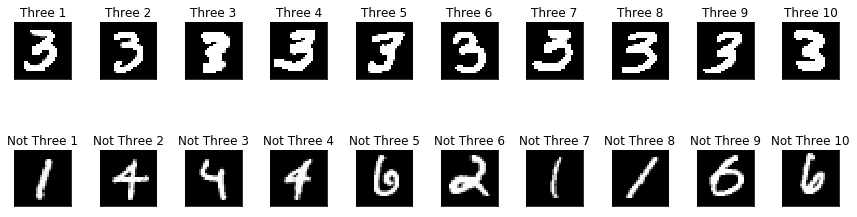

```python
#fig = plt.figure(figsize=(12, 8))
%matplotlib inline
#import matplotlib.pyplot as plt
plt.figure(figsize=(12, 4))
print("Image Samples by Classification Label (n=10)")
for i in range(10):
    three = x_train_q2[y_train_q2 == 1][i]
    notthree = x_train_q2[y_train_q2 == 0][i]
    plt.subplot(2, 10, i+1)
    plt.imshow(three, cmap=plt.cm.gray, vmax=16, interpolation='nearest')
    plt.xticks(())
    plt.yticks(())
    plt.title("Three {}".format(i + 1))
    plt.subplot(2, 10, i+11)
    plt.imshow(notthree, cmap="gray")
    plt.title("Not Three {}".format(i + 1))
    plt.yticks([])
    plt.xticks([])
plt.tight_layout()
```

### C. Classification Distribution and Discussion

```python
from scipy import stats
print(stats.describe(y_train_q2))
print("Number of images labeled as three: ",sum(y_train_q2==1)) #4583
print("Number of images labeled as 'not three': ",sum(y_train_q2==0)) #40417
```

```
DescribeResult(nobs=45000, minmax=(0, 1), mean=0.10184444444444445, variance=0.09147418633994336, skewness=2.6329240017397457, kurtosis=4.932288798937239)
Number of images labeled as three:  4583
Number of images labeled as 'not three':  40417
```

```python
print(len(x_train_q2))
print(x_train_q2.shape)
print(28*28)
```

```
45000
(45000, 28, 28)
784
```

```python
print(y_train_q2.shape)
print(x_train_q2.shape)
#print(x_train_q2[:1])


x_train_ravel = []
#y_train_ravel = []
x_test_ravel = []
#y_test_ravel = []

x_train_ravel = np.zeros((len(y_train_q2), 784))
x_test_ravel = np.zeros((len(y_test_q2), 784))


for i in range(len(y_train_q2)):
    x_train_ravel[i] = x_train_q2[i].ravel()
for i in range(len(y_test_q2)):
    x_test_ravel[i] = x_test_q2[i].ravel()

print(x_train_ravel.shape)
print(x_test_ravel.shape)
```

```
(45000,)
(45000, 28, 28)
(45000, 784)
(15000, 784)
```

### D. Test and Train a Classifier using Cross Validation

Next, I utilized a logistic regression model to fit my image data and predict the classification of the validation data as either "Three" or "Not Three." To do this, I had to change the dimensions of my training dataset to a two diminsional array. to do this, I used .ravel() to roll 28x28 black/white values into a single dimension of length 784.

This classifier achieved an **accuracy score of 97.5%**. I also plotted the confusion matrix for this model.

**Code for D is below:**

```python
from sklearn.linear_model import LogisticRegression
logreg2 = LogisticRegression()

logreg2.fit(x_train_ravel, y_train_q2)
predictions = logreg2.predict(x_test_ravel)

score = logreg2.score(x_test_ravel, y_test_q2)
print(" Model Accuracy Score: ",score)
```

```
 Model Accuracy Score:  0.9746
```

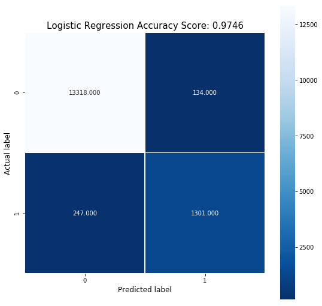

```python
import matplotlib.pyplot as plt
import seaborn as sns
from sklearn import metrics

cm = metrics.confusion_matrix(y_test_q2, predictions)

plt.figure(figsize=(9,9))
sns.heatmap(cm, annot=True, fmt=".3f", linewidths=.5, square = True, cmap = 'Blues_r');
plt.ylabel('Actual label', fontsize=12);
plt.xlabel('Predicted label', fontsize=12);
all_sample_title = 'Logistic Regression Accuracy Score: {0}'.format(score)
plt.title(all_sample_title, size = 15);
```

### Comparing Logistic Regression to Random Chance and "No Threes"

```python
print(predictions.shape)
print(predictions[:10])
pred_ravel = []
pred_ravel = np.zeros((len(y_test_q2), 784))
for i in range(len(y_test_q2)):
    pred_ravel[i] = predictions[i].ravel()

print(pred_ravel.shape)
#print(y_test_q2.shape)
#predictions= pd.DataFrame(predictions)
#predictions= np.array(predictions)
#preds = predictions[:,1]
#print(preds.shape)
```

```
(15000,)
[1 0 0 0 0 1 0 0 0 0]
(15000, 784)
```

```python
import random
chance = np.random.random_integers(0,1,len(y_test_q2))
print(chance.shape)
chance= chance.astype(int)
print(chance[:10])
allzeros = np.zeros((len(y_test_q2), ))
print(allzeros.shape)
allzeros= allzeros.astype(int)
print(allzeros.dtype)
print(allzeros[:10])

chance_ravel = np.zeros((len(y_test_q2), 784))
for i in range(len(y_test_q2)):
    chance_ravel[i] = chance[i].ravel()

zeros_ravel = np.zeros((len(y_test_q2), 784))
for i in range(len(y_test_q2)):
    zeros_ravel[i] = allzeros[i].ravel()
```

```
(15000,)
[1 1 0 0 1 0 0 0 0 1]
(15000,)
int32
[0 0 0 0 0 0 0 0 0 0]
```

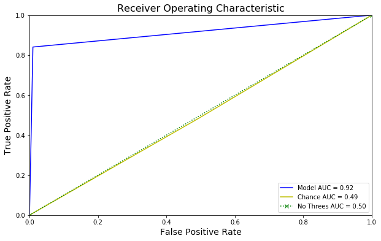

```python
import sklearn.metrics as metrics
# calculate the fpr and tpr for all thresholds of the classification

fig = plt.figure(figsize=(10, 6))
fpr, tpr, threshold = metrics.roc_curve(y_test_q2, pred_ravel[:,1])
roc_auc = metrics.auc(fpr, tpr)

fpr_rand, tpr_rand, threshold_rand = metrics.roc_curve(y_test_q2, chance_ravel[:,1])
roc_auc_rand = metrics.auc(fpr_rand, tpr_rand)

fpr_zeros, tpr_zeros, threshold_zeros = metrics.roc_curve(y_test_q2, zeros_ravel[:,1])
roc_auc_zeros = metrics.auc(fpr_zeros, tpr_zeros)

# method I: plt
import matplotlib.pyplot as plt
plt.title('Receiver Operating Characteristic', fontsize=16)
plt.plot(fpr, tpr, 'b', label = 'Model AUC = %0.2f' % roc_auc)
plt.plot(fpr_rand, tpr_rand, 'y', label = 'Chance AUC = %0.2f' % roc_auc_rand, )
plt.plot(fpr_zeros, tpr_zeros, 'g', label = 'No Threes AUC = %0.2f' % roc_auc_zeros, color='green', marker='x', linestyle='dotted')


plt.legend(loc = 'lower right')
plt.xlim([0, 1])
plt.ylim([0, 1])
plt.ylabel('True Positive Rate', fontsize=14)
plt.xlabel('False Positive Rate', fontsize=14)
plt.show()
```

```
f1=0.872 auc=0.882 ap=0.778
```

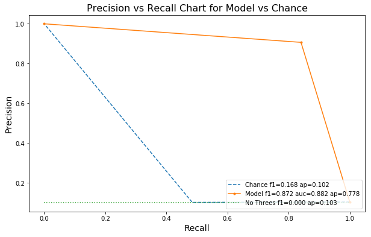

```python
# calculate precision-recall curve

from sklearn.datasets import make_classification
from sklearn.neighbors import KNeighborsClassifier
from sklearn.model_selection import train_test_split
from sklearn.metrics import precision_recall_curve
from sklearn.metrics import f1_score
from sklearn.metrics import auc
from sklearn.metrics import average_precision_score
fig = plt.figure(figsize=(10, 6))

precision, recall, thresholds = precision_recall_curve(y_test_q2, pred_ravel[:,1])
f1 = f1_score(y_test_q2, pred_ravel[:,1])
# calculate precision-recall AUC
auc = auc(recall, precision)
# calculate average precision score
ap = average_precision_score(y_test_q2, pred_ravel[:,1])

precision_rand, recall_rand, thresholds_rand = precision_recall_curve(y_test_q2, chance_ravel[:,1])
f1_rand = f1_score(y_test_q2, chance_ravel[:,1])
#auc_rand = auc(recall_rand, precision_rand)
# calculate average precision score
ap_rand = average_precision_score(y_test_q2, chance_ravel[:,1])

precision_zeros, recall_zeros, thresholds_zeros = precision_recall_curve(y_test_q2, zeros_ravel[:,1])
f1_zeros = f1_score(y_test_q2, zeros_ravel[:,1])
#auc_zeros = auc(recall_zeros, precision_zeros)
# calculate average precision score
ap_zeros = average_precision_score(y_test_q2, zeros_ravel[:,1])





print('f1=%.3f auc=%.3f ap=%.3f' % (f1, auc, ap))
# plot no skill
plt.plot(recall_rand,precision_rand, linestyle='--', label = 'Chance f1=%.3f ap=%.3f' % (f1_rand, ap_rand))
# plot the roc curve for the model
plt.plot(recall, precision, marker='.', label = 'Model f1=%.3f auc=%.3f ap=%.3f' % (f1, auc, ap))
plt.plot([0, 1], [0.1, 0.1], linestyle=':', label = 'No Threes f1=%.3f ap=%.3f' % (f1_zeros, ap_zeros))



# show the plot
plt.xlabel('Recall', fontsize=14)
plt.ylabel('Precision', fontsize=14)
plt.title('Precision vs Recall Chart for Model vs Chance', fontsize=16)
plt.legend(loc="lower right")
plt.show()
```

### Performance Discussion

From these two charts we can see that the Auc and f1 for the logistic regression were much greater tha those for the chance model or "No Threes" model. Therefore, these measures indicate that the trained model performs better than both of these alternatives.

### E? F? Lasso Regularization

I did not have time to finish this part of the question.

However, below is the start I got on exploring Lasso Regularization, with some code I began to modify for my purposes from: https://www.analyticsvidhya.com/blog/2016/01/complete-tutorial-ridge-lasso-regression-python/

In short, Lasso Regression adds penalties equivalent to absolute value of the magnitude of coefficients in a mode. The minimization objective is as follows: LS Obj + α * (sum of absolute value of coefficients).

**Code for e/f below:**

```python
#Importing libraries. The same will be used throughout the article.
import numpy as np
import pandas as pd
import random
import matplotlib.pyplot as plt
%matplotlib inline
from matplotlib.pylab import rcParams
rcParams['figure.figsize'] = 12, 10

#Define input array with angles from 60deg to 300deg converted to radians
x = np.array([i*np.pi/180 for i in range(60,300,4)])
np.random.seed(10)  #Setting seed for reproducability
y = np.sin(x) + np.random.normal(0,0.15,len(x))
data = pd.DataFrame(np.column_stack([x,y]),columns=['x','y'])
plt.plot(data['x'],data['y'],'.')
```

```python
#Import Linear Regression model from scikit-learn.
from sklearn.linear_model import LinearRegression
def linear_regression(data, power, models_to_plot):
    #initialize predictors:
    predictors=['x']
    if power>=2:
        predictors.extend(['x_%d'%i for i in range(2,power+1)])

    #Fit the model
    linreg = LinearRegression(normalize=True)
    linreg.fit(data[predictors],data['y'])
    y_pred = linreg.predict(data[predictors])

    #Check if a plot is to be made for the entered power
    if power in models_to_plot:
        plt.subplot(models_to_plot[power])
        plt.tight_layout()
        plt.plot(data['x'],y_pred)
        plt.plot(data['x'],data['y'],'.')
        plt.title('Plot for power: %d'%power)

    #Return the result in pre-defined format
    rss = sum((y_pred-data['y'])**2)
    ret = [rss]
    ret.extend([linreg.intercept_])
    ret.extend(linreg.coef_)
    return ret
```

```python
#Initialize a dataframe to store the results:
col = ['rss','intercept'] + ['coef_x_%d'%i for i in range(1,16)]
ind = ['model_pow_%d'%i for i in range(1,16)]
coef_matrix_simple = pd.DataFrame(index=ind, columns=col)

#Define the powers for which a plot is required:
models_to_plot = {1:231,3:232,6:233,9:234,12:235,15:236}

#Iterate through all powers and assimilate results
for i in range(1,16):
    coef_matrix_simple.iloc[i-1,0:i+2] = linear_regression(data, power=i, models_to_plot=models_to_plot)
```

**ANSWER**

## 3

### [40 points] Supervised learning exploration

For this exercise, you will construct and implement a supervised learning problem solution/experiment. Describe your process and answer these questions clearly and thoroughly. Part of the grade in this assignment is devoted to the quality and professionalism of your work.

**(a)** Identify a question or problem that's of interest to you and that could be addressed using classification or regression. Explain why it's interesting and what you'd like to accomplish. This should exhibit creativity, and you are not allowed to use the Iris dataset, the Kaggle Titanic dataset, or the Kaggle chocolate dataset.

**(b)** Download the data and plot the data to describe it.

**(c)** Formulate your supervised learning question: (a) What is your target variable (what are you trying to predict) and what predictors do you have available? v Does your dataset require any preprocessing: is it clean (no missing values or erroneous data) and normalized (are each of the predictors of the same magnitude)?

**(d)** What supervised learning technique will you use and why?

**(e)** How will you evaluate performance and know whether you succeeded (e.g. ROC curves for binary classification, mean square error or $R^2$ for regression)?

**(f)** Divide your dataset into training and testing datasets OR implement cross validation. Explain your approach and why you adopted it.

**(g)** Run your analysis and show your performance. Include plots of your data and of performance.

**(h)** Describe how your system performed, where your supervised learning algorithm performed well, and where it did not, and how you could improve it.

**(i)** Write a brief summary / elevator pitch for this work that you would put on LinkedIn to describe this project to future employers. This should focus on the high level impact and importance and overall takeaways and not on the nitty-gritty details.

```python
Attribute Information:

Only 14 attributes used:
1. #3 (age)
2. #4 (sex)
3. #9 (cp)
4. #10 (trestbps)
5. #12 (chol)
6. #16 (fbs)
7. #19 (restecg)
8. #32 (thalach)
9. #38 (exang)
10. #40 (oldpeak)
11. #41 (slope)
12. #44 (ca)
13. #51 (thal)
14. #58 (num) (the predicted attribute)
```

## A. Do young hearts benefit equally from machine learning algorithms?

As one ages, there are few things scarier than thinking of the diseases you may or may not acquire. Some, like cancer, can seem so mysterious and stealthy- sneaking in the shadows to prey on anyone foolish enough to feel safe and comfortable. Other are more steady and methodical killers; they build little by little, often undetected. Heart disease is one of these slow and steady killers.

And so how does one know when they "have heart disease." It turns out, it is not exactly a simple definition.

According to the American Heart Association, "Heart and blood vessel disease (also called heart disease) includes numerous problems, many of which are related to a process called atherosclerosis." It goes on to describe that atherosclerosis is a condition involving plaque that can build up in arteries. The buildup makes it more difficult for blood to pass through the arteries, and clots can stop the flow altoghether. This causes what is known as a heart attack or stroke.$ ^1 $ But to make matters more confusing, the title of this page that describes "heart disease" is titled "cardiovascular-disease".

If you look at mortality statistics for North Carolina, nearly 19,000 people died due to a primary cause of heart disease in 2017.$2$ An additional 5,100 died from cerebrovascular disease (stroke). $3$ Heart disease is the 2nd leading cause of death for all individuals in North Carolina, and the top leading cause of death for residents 65 years of age or older (78% of all NC heart disease deaths).

While genetics play a role in the likelihood someone may be at risk of heart disease, serious outcomes may be prevented and/or mitigated through healthy lifestyle choices such as a balance diet and regular exercise.And so early detection is key to preventing the most serious of complications, including death.

The question I am exploring today is: If a classifier is developed to detect the presence of heart disease in a population, how does that same classifier perform on a younger population? Can the algorithm work equally as well as it does on a full age population on a sample of individuals younger than 50?

To do this analysis I will first use a classifier algorithm to predict if patient data means an individual has the presence of (any level) of heart disease, or no presence of heart disease. I will then run the algorithm on just the young portion of the test data, to see how the performance compares to the full population.

If differences appear, it could provide impetus for research into algorithms based on age of patient.

### B. About the Data

The dataset I selected for this exploration is the Heart Disease data set from the Center for Machine Learning and Intelligent Systems at the University of California, Irvine.$^5$ While rather dated (from 1990), the dataset is publicly available for use and pretty much preprocessed for use, making it a good dataset for learning and practicing my new skills.

The dataset is comprised of patient heart disease diagnosis (measured from 0 to 4), along with patient attributes and measurements. For the purposes of this study, I will classify either the presence of heart disease (1,2,3,or 4) or the absence of heart disease (0) as a binary classification.

The original dataset includes 76 measures, but only 14 measures are used in current published research. As such, these are the measures I plan to include in my classifier.

#### Data Elements

14 attributes used in research:

1. Age
2. Sex
3. Chest pain type
4. Resting blood pressure (in mm Hg on admission to the hospital)
5. Serum cholestoral in mg/dl
6. Fasting blood sugar (fasting blood sugar > 120 mg/dl) (1 = true; 0 = false)
7. Resting electrocardiographic results Value 0: normal $ Value 1: having ST-T wave abnormality (T wave inversions and/or ST elevation or depression of > 0.05 mV) Value 2: showing probable or definite left ventricular hypertrophy by Estes' criteria
8. Maximum heart rate achieved
9. Exercise induced angina (1 = yes; 0 = no)
10. Oldpeak: ST depression induced by exercise relative to rest
11. Slope: the slope of the peak exercise ST segment -- Value 1: upsloping -- Value 2: flat -- Value 3: downsloping
12. Number of major vessels (0-3) colored by flourosopy
13. Thal: 3 = normal; 6 = fixed defect; 7 = reversable defect
14. Diagnosis of heart disease (angiographic disease status) -- Value 0: < 50% diameter narrowing -- Value 1: > 50% diameter narrowing (in any major vessel: attributes 59 through 68 are vessels)

#### Data Quality and Preprocessing

The data have been cleaned and preprocessed prior to downloading. Therefore, the only data cleaning I needed to do was to add identifiers, a binary diagnosis column, and appropriate column names to the data in excel so the data may be loaded into the Jupyter notebook.

```python
import pandas as pd
hd = pd.read_excel("./data/processed.cleveland.data.xlsx")
print("Files Loaded")
```

```
Files Loaded
```

### C. Data Exploration

There are 303 patients in this dataset. The **mean age is 54**, with range (29,77). The sample is **67% male** (sex=1). Approximately **46% percent** of the population has a diagnosis of heart disease.

These data points are important to consider as we now divide the data into test and train, as ultimately we want the samples to be representative. With fairly balanced demographics, there is less likelihood that a test dataset may be unrepresentative of the full sample by chance.

Other predictors appear as one may expect with a greater percentage of those diagnosed with heart disease identified as having the most severe chest pain. However, somewhat surprising, there were more with slight chest pain who were identified as having heart disease than in the moderate chest pain categories. Perhaps, this could say something about whether an individual is recently diagnosed or experiencing symptoms for the first time.

There is a right skew in distribution of blood pressure values, which makes sense because even in the general population, high blood pressure is more common than low blood pressure on average. The bulk of blood pressure values fall in the normal or high range (roughly 110-150 mm Hg), with several measuremetns dangerously high (>180 mm Hg).

```python
print(hd.shape)  # Uploaded Correctly
print(hd.describe()) # fairly balanced in terms of age and sex
print(hd.isnull().sum()) # a few null values
hd = hd.dropna()
print(hd.isnull().sum()) # remove null values
```

```
(303, 16)
               ID         age         sex          cp    trestbps        chol  \
count  303.000000  303.000000  303.000000  303.000000  303.000000  303.000000
mean   152.000000   54.438944    0.679868    3.158416  131.689769  246.693069
std     87.612784    9.038662    0.467299    0.960126   17.599748   51.776918
min      1.000000   29.000000    0.000000    1.000000   94.000000  126.000000
25%     76.500000   48.000000    0.000000    3.000000  120.000000  211.000000
50%    152.000000   56.000000    1.000000    3.000000  130.000000  241.000000
75%    227.500000   61.000000    1.000000    4.000000  140.000000  275.000000
max    303.000000   77.000000    1.000000    4.000000  200.000000  564.000000

              fbs     restecg     thalach       exang     oldpeak       slope  \
count  303.000000  303.000000  303.000000  303.000000  303.000000  303.000000
mean     0.148515    0.990099  149.607261    0.326733    1.039604    1.600660
std      0.356198    0.994971   22.875003    0.469794    1.161075    0.616226
min      0.000000    0.000000   71.000000    0.000000    0.000000    1.000000
25%      0.000000    0.000000  133.500000    0.000000    0.000000    1.000000
50%      0.000000    1.000000  153.000000    0.000000    0.800000    2.000000
75%      0.000000    2.000000  166.000000    1.000000    1.600000    2.000000
max      1.000000    2.000000  202.000000    1.000000    6.200000    3.000000

               ca        thal         num        diag
count  299.000000  301.000000  303.000000  303.000000
mean     0.672241    4.734219    0.937294    0.458746
std      0.937438    1.939706    1.228536    0.499120
min      0.000000    3.000000    0.000000    0.000000
25%      0.000000    3.000000    0.000000    0.000000
50%      0.000000    3.000000    0.000000    0.000000
75%      1.000000    7.000000    2.000000    1.000000
max      3.000000    7.000000    4.000000    1.000000
ID          0
age         0
sex         0
cp          0
trestbps    0
chol        0
fbs         0
restecg     0
thalach     0
exang       0
```

[output cut: 9 more lines]

```
sex         0
cp          0
trestbps    0
chol        0
fbs         0
restecg     0
thalach     0
exang       0
oldpeak     0
slope       0
ca          0
thal        0
num         0
diag        0
dtype: int64
```

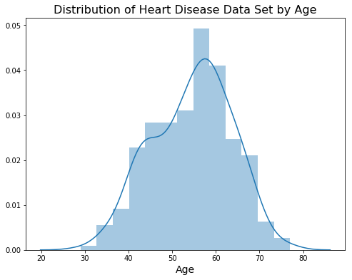

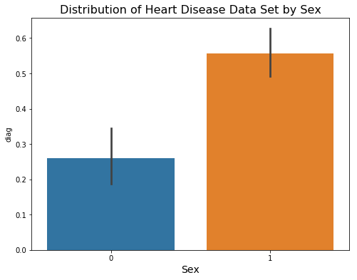

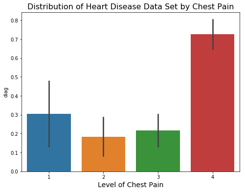

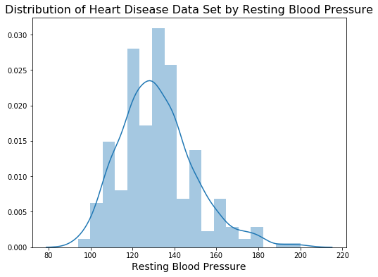

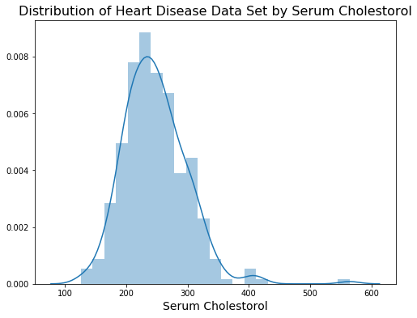

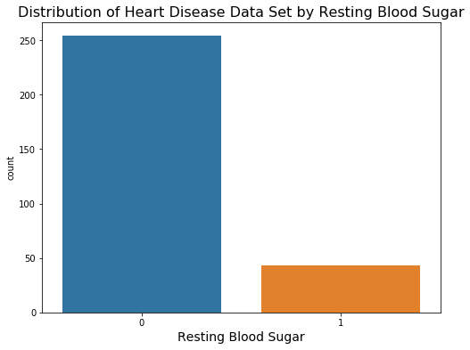

```python
import matplotlib.pyplot as plt
# Independent Variables

## age
#fig = plt.figure(figsize=(12, 8))
#sns.countplot(x="age", data=hd)
#plt.title("Distribution of Heart Disease Data Set by Age")
#plt.show()

## age 2
fig = plt.figure(figsize=(8, 6))
sns.distplot(hd['age'])
plt.xlabel("Age",fontsize=14)
plt.title("Distribution of Heart Disease Data Set by Age", fontsize=16)
plt.show()


## sex
fig = plt.figure(figsize=(8, 6))
#sns.countplot(x="sex", data=hd)
sns.barplot(x="sex", y="diag", data=hd)
plt.xlabel("Sex",fontsize=14)
plt.title("Distribution of Heart Disease Data Set by Sex",fontsize=16)
plt.show()

## Chest pain
fig = plt.figure(figsize=(8, 6))
#sns.countplot(x="cp", data=hd)
sns.barplot(x="cp", y="diag", data=hd)
plt.xlabel("Level of Chest Pain",fontsize=14)
plt.title("Distribution of Heart Disease Data Set by Chest Pain",fontsize=16)
plt.show()

## Resting Blood Pressure
fig = plt.figure(figsize=(8, 6))
sns.distplot(hd['trestbps'])
plt.xlabel("Resting Blood Pressure",fontsize=14)
plt.title("Distribution of Heart Disease Data Set by Resting Blood Pressure",fontsize=16)
plt.show()

## Cholestorol
fig = plt.figure(figsize=(8, 6))
sns.distplot(hd['chol'])
#sns.barplot(x="", y="diag", data=hd)
plt.xlabel("Serum Cholestorol",fontsize=14)
plt.title("Distribution of Heart Disease Data Set by Serum Cholestorol",fontsize=16)
plt.show()

## Fasting Blood Sugar
fig = plt.figure(figsize=(8, 6))
sns.countplot(hd['fbs'])
plt.xlabel("Resting Blood Sugar",fontsize=14)
plt.title("Distribution of Heart Disease Data Set by Resting Blood Sugar",fontsize=16)
plt.show()
```

### D and E. Choosing a classification model

For this exploration, I decided to use a logistic regression, as the outcome variable is binary, and logistic regression is typically good for this kind of classification with both categorical and continuous variables and a binary outcome. If I have time, and depending on the results of my classifier, I would like to also take a shot at a second kind of model using all the different "categories" of heart disease.

However, for the first attempt, I will use a logistic regression. I tried both cross validation and a data split to assess my model performance (but not together).Ultimately, I settled with the splitting of data although I would have prefered cross validation using k-folds becauese my dataset is small and I want to reduce over-fit by using multiple folds. However. I enountered coding issues and had to stick with the divided dataset.

### F. Dividing the Datasets

```
Index(['ID', 'age', 'cp', 'trestbps', 'chol', 'restecg', 'thalach', 'oldpeak',
       'slope', 'ca', 'thal', 'num', 'diag', 'sex_0', 'sex_1', 'fbs_0',
       'fbs_1', 'exang_0', 'exang_1'],
      dtype='object')
```

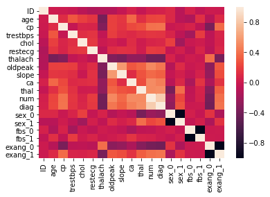

```
(297, 19)
(222, 18)
```

[output not shown]

[output cut: 47 more lines]

```python
import warnings

from sklearn import datasets, linear_model
from sklearn.model_selection import train_test_split
from matplotlib import pyplot as plt
from sklearn.linear_model import LogisticRegression
from sklearn.cross_validation import train_test_split
import seaborn as sns


hd2 = pd.get_dummies(hd, columns =['sex','fbs','exang'])
print(hd2.columns)
#data2.drop(data2.columns[[12, 16, 18, 21, 24]], axis=1, inplace=True)
#data2.columns
sns.heatmap(hd2.corr())
plt.show()
print(hd2.shape)
y = hd2.iloc[:,-7]




hd3=hd2.drop(['diag'], axis=1)
X= hd3
X_train, X_test, y_train, y_test = train_test_split(X, y, random_state=16)
print(X_train.shape)
y_train.head
```

### Building the Model

```python
from sklearn.linear_model import LogisticRegression
from sklearn.cross_validation import train_test_split

logclassifier = LogisticRegression(random_state=16)
logclassifier.fit(X_train, y_train)
```

```
LogisticRegression(C=1.0, class_weight=None, dual=False, fit_intercept=True,
          intercept_scaling=1, max_iter=100, multi_class='ovr', n_jobs=1,
          penalty='l2', random_state=16, solver='liblinear', tol=0.0001,
          verbose=0, warm_start=False)
```

#### Training the Model

```python
y_pred = logclassifier.predict(X_test)
from sklearn.metrics import confusion_matrix
confusion_matrix = confusion_matrix(y_test, y_pred)
print(confusion_matrix)
```

```
[[41  0]
 [ 0 34]]
```

### G. Performance Evaluation

Given this dataset is small, it may be reasonable to expect a high AUC. However perfect prediction makes me skeptical, and so I explored the methods of PCA to check my model performance further. Unfortunately, this too presented some coding issues and I was unable to fully implement this part of the evaluation. With more time I would hope to figure out why my algorithm was performing with perfect prediction, as I expect it is an error.

```python
print('Accuracy of logistic regression classifier on test set: {:.2f}'.format(logclassifier.score(X_test, y_test)))

from sklearn.metrics import classification_report
print(classification_report(y_test, y_pred))
```

```
Accuracy of logistic regression classifier on test set: 1.00
             precision    recall  f1-score   support

          0       1.00      1.00      1.00        41
          1       1.00      1.00      1.00        34

avg / total       1.00      1.00      1.00        75
```

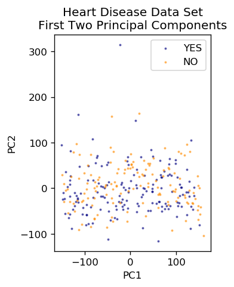

```python
from sklearn.decomposition import PCA
X_pca = hd3
y_pca = hd2.iloc[:,-7]
pca = PCA(n_components=2).fit_transform(X_pca)
X_pca_train, X_pca_test, y_pca_train, y_pca_test = train_test_split(pca, y_pca, random_state=0)

plt.figure(dpi=120)
plt.scatter(pca[y.values==0,0], pca[y.values==0,1], alpha=0.5, label='YES', s=2, color='navy')
plt.scatter(pca[y.values==1,0], pca[y.values==1,1], alpha=0.5, label='NO', s=2, color='darkorange')
plt.legend()
plt.title('Heart Disease Data Set\nFirst Two Principal Components')
plt.xlabel('PC1')
plt.ylabel('PC2')
plt.gca().set_aspect('equal')
plt.show()
```

```python
import numpy as np
from numpy import meshgrid
from matplotlib import pyplot as plt

def plot_hd(X, y, fitted_model):
    plt.figure(figsize=(9.8,5), dpi=100)
    for i, plot_type in enumerate(['Decision Boundary', 'Decision Probabilities']):
        plt.subplot(1,2,i+1)
        mesh_step_size = 0.01  # step size in the mesh
        x_min, x_max = X[:, 0].min() - .1, X[:, 0].max() + .1
        y_min, y_max = X[:, 1].min() - .1, X[:, 1].max() + .1
        xx, yy = np.meshgrid(np.arange(x_min, x_max, mesh_step_size), np.arange(y_min, y_max, mesh_step_size))
        if i == 0:
            Z = fitted_model.predict(np.c_[xx.ravel(), yy.ravel()])
        else:
            try:
                Z = fitted_model.predict_proba(np.c_[xx.ravel(), yy.ravel()])[:,1]
            except:
                plt.text(0.4, 0.5, 'Probabilities Unavailable', horizontalalignment='center', verticalalignment='center', transform = plt.gca().transAxes, fontsize=12)
                plt.axis('off')
                break
        Z = Z.reshape(xx.shape)
        plt.scatter(X[y.values==0,0], X[y.values==0,1], alpha=0.8, label='YES', s=5, color='navy')
        plt.scatter(X[y.values==1,0], X[y.values==1,1], alpha=0.8, label='NO', s=5, color='darkorange')
        plt.imshow(Z, interpolation='nearest', cmap='RdYlBu_r', alpha=0.15,extent=(x_min, x_max, y_min, y_max), origin='lower')
        plt.title(plot_type + '\n' + str(fitted_model).split('(')[0]+ ' Test Accuracy: ' + str(np.round(fitted_model.score(X, y), 5)))
        plt.gca().set_aspect('equal');
    plt.tight_layout()
    plt.legend()
    plt.subplots_adjust(top=0.9, bottom=0.08, wspace=0.02)
```

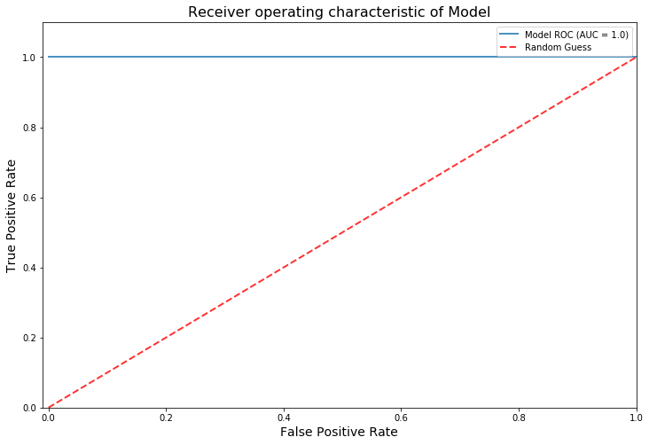

```python
from sklearn import svm, datasets
from sklearn.metrics import roc_curve, auc
from sklearn.model_selection import train_test_split
from sklearn.preprocessing import label_binarize
from sklearn.multiclass import OneVsRestClassifier
from scipy import interp

fpr_log, tpr_log, thresholds_log = roc_curve(y_test, y_pred)
roc_auc_log = auc(fpr_log, tpr_log)
plt.figure(figsize=(12, 8))
plt.plot(fpr_log, tpr_log,
         label='Model ROC (AUC = {:.4})'.format(roc_auc_log),
         lw=2, alpha=.8)
plt.plot([0, 1], [0, 1], linestyle='--', lw=2, color='r',
         label='Random Guess', alpha=.8)
plt.xlabel('False Positive Rate', fontsize=14)
plt.ylabel('True Positive Rate', fontsize=14)
plt.title('Receiver operating characteristic of Model', fontsize=16)
plt.ylim([0.0, 1.1])
plt.xlim([-0.01, 1.0])
plt.legend()
plt.show()
```

```python
print(X_pca_test.shape)
print(y_pca_test.shape)
```

### Experiment: Narrow test data to younger population

```python
print(X_test.shape)
print(y_test.shape)
X2_test = X_test
y2_test = y_test
regroup=  pd.concat([X2_test,y2_test], axis=1, join_axes=[X2_test.index])

regroup.shape

younger= regroup[regroup['age'] <50]

younger.shape
#younger.head
```

```
(75, 18)
(75,)
```

```
(22, 19)
```

```python
y_young = younger.iloc[:,-1]
X_young=younger.drop(['diag'], axis=1)

#print(y_young.head)
#print(X_young.head)
young_pred = logclassifier.predict(X_young)
from sklearn.metrics import confusion_matrix
confusion_matrix = confusion_matrix(y_young, young_pred)
print(confusion_matrix)
```

```
[[14  0]
 [ 0  8]]
```

#### Repeat Testing model and performance evaluation

#### Findings

The model still performs quite well. However, this test sample WAS well balanced. Therefore, I wonder if I trained on just the older half, if it would then have a harder time working on the test data. To do this, I'll need to re-train a new classifier using the test data that is only the older population.

### Experiment 2: Narrow Training data to older population

```python
print(X_train.shape)
print(y_train.shape)
X2_train = X_train
y2_train = y_train
regroup_train=  pd.concat([X2_train,y2_train], axis=1, join_axes=[X2_train.index])

regroup_train.shape

older= regroup_train[regroup_train['age'] >=50]

older.shape
#older.head
```

```
(222, 18)
(222,)
```

```
(159, 19)
```

```python
classifier_old = LogisticRegression(random_state=16)
classifier_old.fit(X2_train, y2_train)
```

```
LogisticRegression(C=1.0, class_weight=None, dual=False, fit_intercept=True,
          intercept_scaling=1, max_iter=100, multi_class='ovr', n_jobs=1,
          penalty='l2', random_state=16, solver='liblinear', tol=0.0001,
          verbose=0, warm_start=False)
```

```python
y_pred_mix = classifier_old.predict(X_young)
from sklearn.metrics import confusion_matrix
confusion_matrix = confusion_matrix(y_young, y_pred_mix)
print(confusion_matrix)
```

```
[[14  0]
 [ 0  8]]
```

Sources:

1. https://www.heart.org/en/health-topics/consumer-healthcare/what-is-cardiovascular-disease
2. https://schs.dph.ncdhhs.gov/data/vital/lcd/2017/heartdisease.html
3. https://schs.dph.ncdhhs.gov/data/vital/lcd/2017/cerebrovascular.
4. https://schs.dph.ncdhhs.gov/data/vital/lcd/2017/pdf/TblsA-F.pdf
5. https://archive.ics.uci.edu/ml/datasets/Heart+Disease

Additional Credits: Coding based on tutorial by Susan Li, https://datascienceplus.com/author/susan-li/

**ANSWER**